```
                                    Taller Repaso
                                  Analisis Numerico
                 Por:
                 Nicolai Barrera
                 Diego Burgos

                 Para:
                 Profesora Eddy Herrera Daza
```

## ——————————————————————————————-

1. Suponga que un dispositivo solo puede almacenar únicamente los cuatro primeros dígitos decimales de cada número real, y trunca los restantes (esto es redondeo inferior). Calcule el error de redondeo si se quiere almacenar el número 536.78

```r
redondear <- function (numero, dig){ #Recibe como parametro Numero a redondear y digitos deseados
  contador=0
  while(numero>1){ #divide y cuenta cuantas divisiones
    numero<-numero/10
    contador=contador+1
  }

  E<-(numero-trunc(numero*10^4)/10^4)# obtiene el numero redondeado

  izq<-1*10^(contador-dig)
  der<-1*10^(contador-dig)
  cat("El error es de ",izq,"<",E,"Y",E,"<",der)
}
redondear(536.78,4)
```

```
## El error es de  0.1 < 8e-05 Y 8e-05 < 0.1
```

## ——————————————————————————————-

2.Implemente en cualquier lenguaje el siguiente algoritmo que sirve para calcular la raíz cuadrada. Aplíquelo para evaluar la raíz cuadrada de 7, analice su precisión, como podría evaluar la convergencia y validez del algoritmo.

```r
raiz <- function(numero, valor, tolerancia){ #La funcion recibe el numero a calcular
                                            #junto con un valor inicial y el error que se puede permitir
  resul<-((0.5)*(valor+(numero/valor))) #valor aproximado del calculo raiz de 7


  while(abs(valor-resul) > tolerancia) #calculando el valor hasta que no exeda el error permitido
  {
    valor<- resul
    resul<- (0.5)*(valor+(numero/valor))

  }
  return(cat("La raiz da:", resul, ", el error permitido es de:", tolerancia))
}

raiz(7,3,0.000001)
```

```
## La raiz da: 2.645751 , el error permitido es de: 1e-06
```

## ——————————————————————————————-

3.Utilizando el teorema de Taylor hallar la aproximación de e^(0.5) con cinco cifras significativas

```r
PolinomioTaylor <- function(exponente,cifras){ #la funcion recibe un exponente y las cifras que quiero mostrar (5)
  iterador<-cifras-1
  sumaTotal <-1

  while(iterador>0){
    sumaTotal <- 1+(exponente*sumaTotal)/iterador
    iterador<-iterador-1
  }
  resultado <- signif(sumaTotal,digits=cifras) # (signif)acota el resultado a la cantidad de cifras que necesita
  cat("La aproximancion de e^0.5 es:",resultado)
}

PolinomioTaylor(0.5,5)
```

```
## La aproximancion de e^0.5 es: 1.6484
```

## ——————————————————————————————-

4.Calcule el error de la solucion de el siguiente problema: La velocidad d euna particula es constante e igual a 4 m/s, media con un error de 0.1 m/s durante el tiempo de recorrudo de 5 seg. Medido con un error de 0.1 seg. DeterMinimosimose el error absoluto y el error relativo en el valor de la distancia arrecorrida d =vt

```r
DistanciaEror<- function (velocidad,errorVel,tiempo,errorTiem) #recibe los datos para calcular distancia y sus respectivos errores
{
  distancia<- velocidad*tiempo #calcula la distancia
  errorRela = (errorVel/velocidad)+(errorTiem/tiempo) #calculo error relativo
  errorAbso = (velocidad*errorVel)+(tiempo*errorTiem) #calculo error absoluto
  cat("La distancia calculada es:" ,distancia, "\n","Error absoluto: ",errorAbso, " \n Error RElativo: ",errorRela)

}
DistanciaEror(4,0.1,5,0.1)
```

```
## La distancia calculada es: 20
##  Error absoluto:  0.9
##  Error RElativo:  0.045
```

## ——————————————————————————————-

```r
polinomio<- function (x0)
{

  resultado <- (2*x0^4)-(3*x0^2)+(3*x0) - 4 #polinomio dado en el enunciado reemplazado en x
  cat("El resultado de reemplazar X0 fue:",resultado)
}

polinomio(-2)
```

```
## El resultado de reemplazar X0 fue: 10
```

## ——————————————————————————————-

6.Reconstruir la silueta del perrito utilizando la menor cantidad de puntos para reproducir el dibujo del contorno completo del perrito sin bigotes, con la información dada:

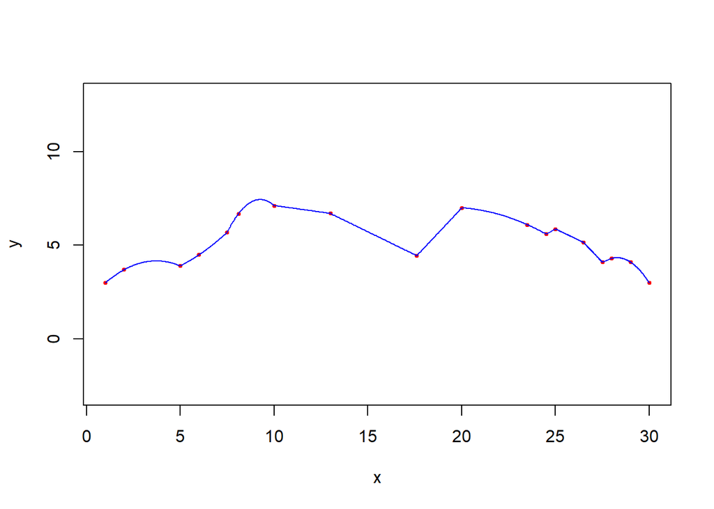

```
## bool 1 Minimos 1 Maximos 3 cont 2 <>0
## bool 1 Minimos 3 Maximos 5 cont 2 <>0
## bool 1 Minimos 5 Maximos 7 cont 2 <>0
## bool 1 Minimos 7 Maximos 8 cont 1 <0
## bool 0 Minimos 8 Maximos 9 cont 2 >0
## bool 1 Minimos 9 Maximos 10 cont 2 <0
## bool 0 Minimos 10 Maximos 12 cont 2 <>0
## bool 0 Minimos 12 Maximos 13 cont 1 >0
## bool 1 Minimos 13 Maximos 14 cont 1 <0
## bool 0 Minimos 14 Maximos 15 cont 2 >0
## bool 1 Minimos 15 Maximos 16 cont 2 <0
## bool 0 Minimos 16 Maximos 18 cont 2 <>0
## bool 0 Minimos 18 Maximos 18 cont 0 <>0
```

```r
library(PolynomF)

require(PolynomF)


x=c(1,2,5,6,7.5,8.1,10,13,17.6,20,23.5,24.5,25,26.5,27.5,28,29,30)
y=c(3,3.7,3.9,4.5,5.7,6.69,7.12,6.7,4.45,7,6.1,5.6,5.87,5.15,4.1,4.3,4.1,3) # se definen los puntos que seran graficados en la grafica
plot(x,y, pch=19, cex=0.5, col = "red", asp=1)
i= 1
Minimos = i
Maximos = i+1
bool = 0
cont = 1

repeat
{
  m = (y[i+1]-y[i])/(x[i+1]-x[i])#
  cont = cont +1
  if (i == 1 && m > 0)
  {
    bool = 1}
  else if(i == 1 && m < 0)
  {
    bool = 0}
  if (m < 0)
  {
    if (bool == 0)
    {
      j = i + 1
      Maximos= j
      i = j
    }
    else
    {

      datx = x[Minimos:Maximos]; daty = y[Minimos:Maximos]
      polyAjuste = poly_calc(datx, daty)
      cat("bool", bool, "Minimos", Minimos, "Maximos", Maximos, "cont", cont-1,"<0\n")
      curve(polyAjuste,from=x[Minimos],to=x[Maximos],add=T, lwd=1,col="blue")
      Minimos = Maximos
      cont = 1
      bool = 0
      i = Maximos
      j = i + 1
      Maximos= j
    }
  }
  else
  {
    if (bool == 0)
    {
      datx = x[Minimos:Maximos]; daty = y[Minimos:Maximos]
      polyAjuste = poly_calc(datx, daty)
      cat("bool", bool, "Minimos", Minimos, "Maximos", Maximos, "cont", cont-1,">0\n")
      curve(polyAjuste,from=x[Minimos],to=x[Maximos],add=T, lwd=1,col="blue")
      Minimos = Maximos
      cont = 1
      bool = 1
      i = Maximos
      j = i + 1
      Maximos= j
    }
    else
    {
      j = i + 1
      Maximos= j
      i = j
    }
  }
  if (cont == 3)
  {
    datx = x[Minimos:Maximos]; daty = y[Minimos:Maximos]
    polyAjuste = poly_calc(datx, daty)
    cat("bool", bool, "Minimos", Minimos, "Maximos", Maximos, "cont", cont-1,"<>0\n")
    curve(polyAjuste,from=x[Minimos],to=x[Maximos],add=T, lwd=1,col="blue")
    Minimos = Maximos
    cont = 1
    i = Maximos
    j = i + 1
    Maximos= j

    if(m < 0)
    {
      bool = 0
    }
    else
    {
      bool = 1
    }
  }

  if (i==length(x))
  {
    Maximos = i
    datx = x[Minimos:Maximos]; daty = y[Minimos:Maximos]
    polyAjuste = poly_calc(datx, daty)
    cat("bool", bool, "Minimos", Minimos, "Maximos", Maximos, "cont", cont-1,"<>0\n")
    curve(polyAjuste,from=x[Minimos],to=x[Maximos],add=T, lwd=1,col="blue")
    break;
  }
}
```